# DE and Pathway Analysis

# DE analysis with DESeq2

Here, we will use the established log fold-change threshold. To be clear, this is set at 1,20 and is used in absolute terms (meaning <=-1,20 and >=1,20 are of sufficient use). To do the DE analysis, we will use the `DESeq2` library, which was renounced for its negative binomial distribution.

```r
degs <- de_analysis(counts, meta.sepsis, low.exp = 10,
                    design.element = "sepsis_severity", fold_thres = 1.2)

# Non unique DEGs
lapply(degs$results, function(x) summary_de(x)) %>%
  bind_rows() %>%
  mutate(comparison = names(degs$results)) %>%
  dplyr::select(comparison, everything()) %>%
  kable(format = 'html', booktabs = TRUE) %>%
  kable_styling(full_width = FALSE, position = "center",
                bootstrap_options = c("striped", "hover"))
```

| comparison | all_degs | up_degs | down_degs |
| --- | --- | --- | --- |
| Intermediate_against_High | 19 | 8 | 11 |
| Low_against_High | 181 | 71 | 110 |
| Low_against_Intermediate | 43 | 20 | 23 |

We do the same for mortality and discover there are no DEGs are found in any comparison here. The only essential comparison is of course `survived_against_deceased`, as the other two are against former NA valuations. Therefore, as these are zero DEGs for mortality, we will primarily focus on clustering the DEGs found with severity.

```r
mort <- de_analysis(counts, meta.sepsis, low.exp = 10,
                    design.element = "mortality", fold_thres = 1.2)

lapply(mort$results, function(x) summary_de(x)) %>%
  bind_rows() %>%
  mutate(comparison = names(mort$results)) %>%
  select(comparison, everything()) %>%
  kable(format = 'html', booktabs = TRUE) %>%
  kable_styling(full_width = FALSE, position = "center",
                bootstrap_options = c("striped", "hover"))
```

| comparison | all_degs | up_degs | down_degs |
| --- | --- | --- | --- |
| survived_against_deceased | 0 | 0 | 0 |
| unknown_against_deceased | 0 | 0 | 0 |
| unknown_against_survived | 0 | 0 | 0 |

We plot some MA plots below to give some visualizations of how the non-significant and significant genes are distributed. These are highlighted in black and red, respectfully. High vs. Low yielded the most DEGs.

```r
ma.severity <- Map(function(comparison, name) {
  comparison %>% as.data.frame() %>%
    mutate(mean_count = rowMeans(counts(degs$dds, normalized = TRUE))) %>%
    ggplot(aes(x = mean_count, y = log2FoldChange)) +
    geom_point(aes(color = ifelse(de == "DE", "Significant", "Not significant"))) +
    scale_x_log10() +
    ggtitle(glue::glue("MA plot for {name}")) +
    labs(x= "Mean normalized count", y="Log2 fold change", color = "Status") +
    scale_color_manual(values = c("black", "red"))
}, degs$results, names(degs$results))

# Normalize the gene set with VST normalization and batch correction
normalized.counts <- normalize(counts, meta.sepsis)
```

```
## Found 146 genes with uniform expression within a single batch (all zeros); these will not be adjusted for batch.
```

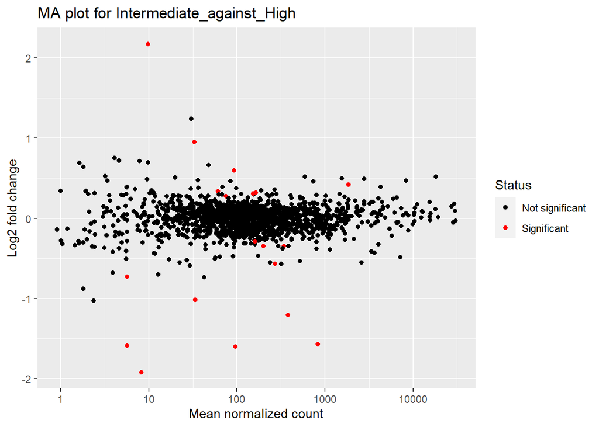

MA plot for Intermediate vs. High; not significant in black and significant in red.

```r
plot(ma.severity[[1]])
```

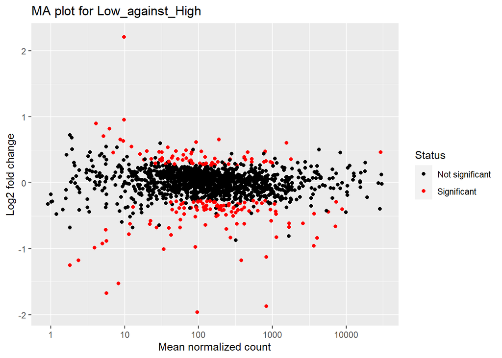

MA plot for Low vs. High; not significant in black and significant in red.

```r
plot(ma.severity[[2]])
```

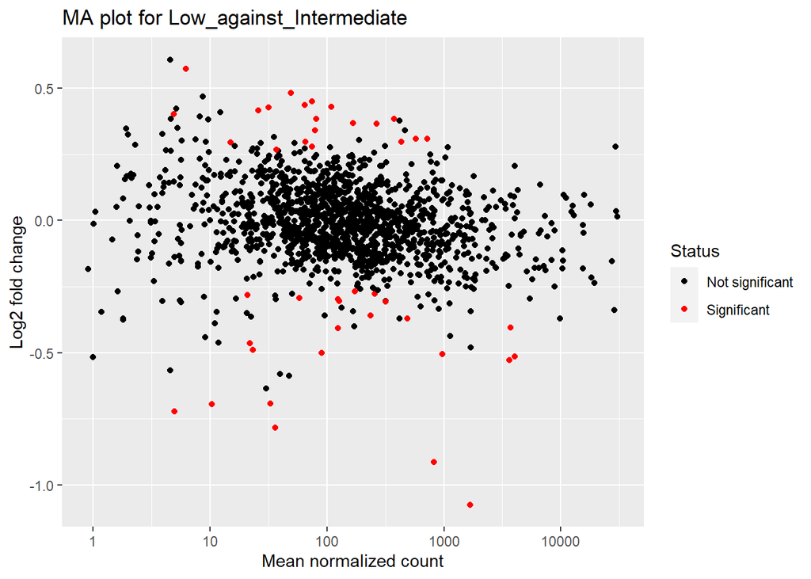

MA plot for Intermediate vs. Low; not significant in black and significant in red.

```r
plot(ma.severity[[3]])
```

We do some quality checks by using a dispersion plot, as depicted below. Here, the red curve represents the expected dispersion trend, and it is common to see this line decrease and stabilize as the mean normalized counts increase. The black dots (dispersion estimates) follow the trend line, which is good and suggests a fitting that is well. However, there are some outliers here (at the lower end), but they are not extreme. Finally, the blue dots suggest the final dispersion estimates (used in DE testing) are similar to the black dots, indicating that the model has done a good job of estimating the dispersion.

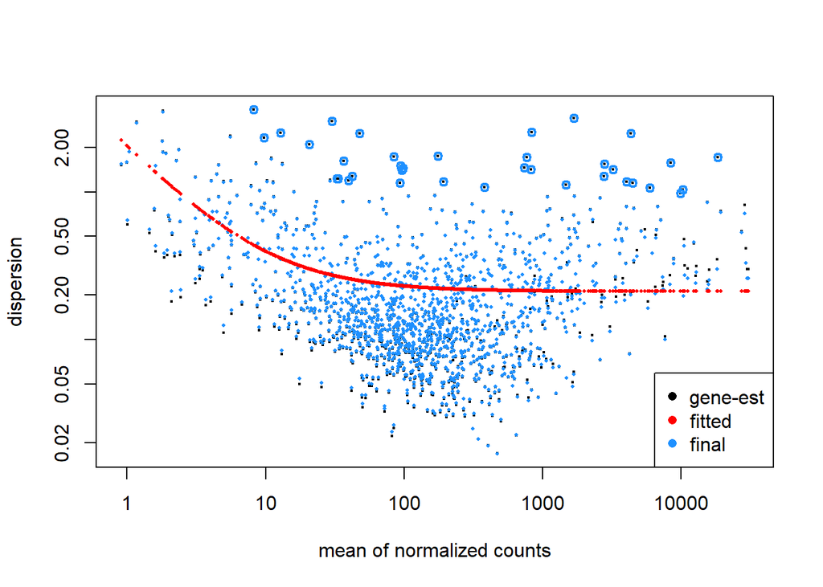

Dispersion estimates for severity. The red line indicates the trend line and decreases gradually. Most genes are between 0.02 (low) and 2.00 (higher) dispersion. Since genes with high dispersion have similar average expression levels as genes with more typical dispersion, it could reflect the tightly regulation that is part of mitochondria.

```r
plotDispEsts(degs$dds)
```

In this section, we simply extract the found DEGs from the counts dataset by using the functions `gene_set_slicer` and `gene_slicer`. The first function is used in `gene_slicer` and is some kind of wrapper function, but it can also be used outside of the `gene_slicer` function. These two functions have some different behavior depending on the DE method used, especially in parameter names (e.g., using `padj` for DESeq2 and `FDR` in edgeR). The primary function of `gene_set_slicer` is to slice the count set to have unique DEGs left. Since the DEG sets found in different comparisons can overlap, the main function of `gene_slicer` is to make sure only unique DEG names are given to `gene_set_slicer`.

After performing a `dim` on `all_genes`, we can conclude that the total DEG population for severity is 201, based on all ER and ICU samples.

```r
gene_set_slicer <- function(df, genes, n) {

  # Difference between edgeR and DESeq2
  if (class(genes) == 'DESeqResults') {
    pvald <- 'padj'
    logFC <- 'log2FoldChange'
    change <- 'absolute_change'
  } else {
    pvald <- 'FDR'
    logFC <- 'logFC'
    change <- 'logFC'
  }

  # Extract signficant genes
  sig_genes <- genes %>% as.data.frame() %>%
    filter(direction != "NOT_SIG") %>%
    arrange(desc(!!change)) %>%
    # Slice depending how large the set has to be
    slice(1:n)

  reduced_df <- df %>% as.data.frame() %>%
    filter(row.names(.) %in% row.names(sig_genes)) %>%
    rownames_to_column('gene')

  return(reduced_df)
}

gene_slicer <- function(normalized.set, gene_set, amount, type='deseq2') {
  # use a large amount to get all DEGs, instead of a fixed number
  if (amount == "all") {amount <- 999999}
  if (type == "deseq2") {gene_set <- gene_set$results}

  result <- lapply(gene_set, function(comparison) {
    gene_set_slicer(normalized.set, comparison, amount)} %>%
    # Merge into one dataset
    t() %>% as.data.frame() %>%
    rownames_to_column('id')) %>%
    # Apply on every list at once; id = sample_id
    purrr::reduce(dplyr::left_join, by = 'id') %>%
    column_to_rownames('id') %>%
    t() %>% as.data.frame() %>%
    distinct(gene, .keep_all = T)

  # Delete rownames, since there are already existing ones,
  # we do it outside the loop
  row.names(result) <- result[, 'gene']
  result <- result %>% dplyr::select(-gene) %>%
    mutate(across(where(is.character), as.numeric))

  return(result)
}

# Slice genes with different sizes
fivety_genes <- gene_slicer(normalized.counts, degs, 50)
hunderth_genes <- gene_slicer(normalized.counts, degs, 100)
all_genes <- gene_slicer(normalized.counts, degs, "all")

dim(all_genes)
```

```
## [1] 201 348
```

```r
plot_pca <- function(gene_set, target) {
  # Perform PCA
 pca_res <- perform_pca(gene_set)

 # Get the variance
 vars <- pca_res$eigenvalues$pva
  pca_res$pca$x %>%
    as.data.frame() %>%
    rownames_to_column('sample_identifier') %>%
    # merge with meta to have access to the target variable
    full_join(x = ., y = meta.sepsis, by = 'sample_identifier') %>%
    ggplot(aes(x = PC1, y = PC2, color = !!sym(target))) +
    geom_point(size=2) +
    labs(title = "PCA - based on DEG set", color = "Sepsis Severity Status") +
    xlab(glue::glue("PC1: {round(vars[1], 2)}%")) +
    ylab(glue::glue("PC2: {round(vars[2], 2)}%"))
}
```

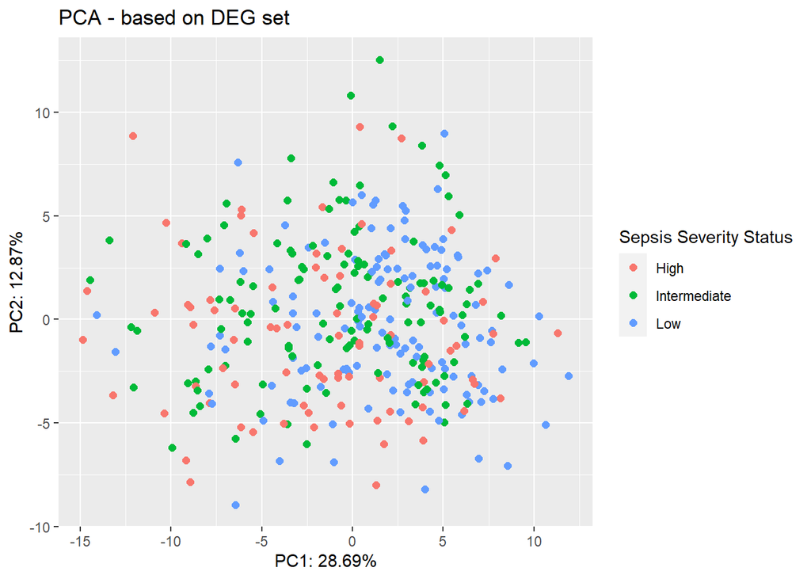

PCA plot for the 50 most-contributing genes. Variance in PC1 is 28.7%.

```r
plot_pca(fivety_genes, 'sepsis_severity')
```

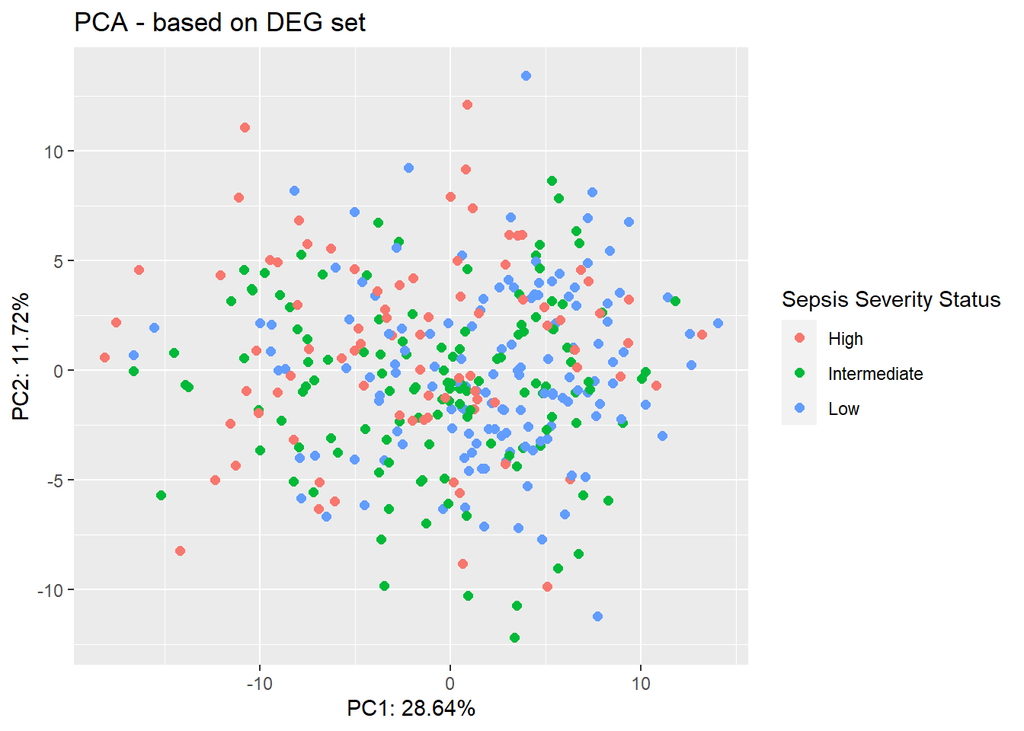

```r
plot_pca(hunderth_genes, 'sepsis_severity')
```

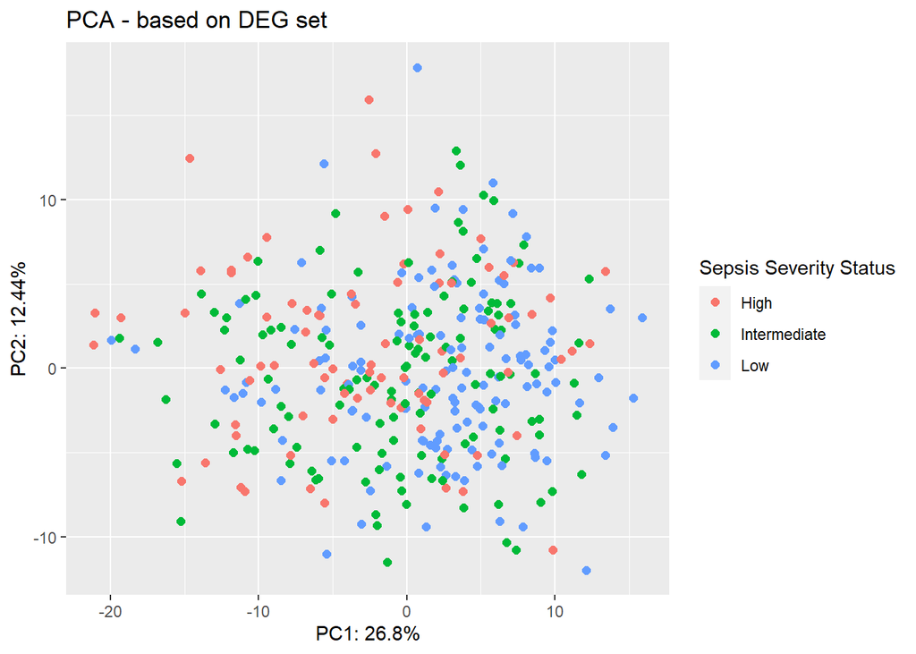

```r
plot_pca(all_genes, 'sepsis_severity')
```

Next, we construct three heatmaps with the gene expression of all 201 DEGs. We perform this on the three gene sets to observe the influence of adding more DEGs. It might be the case that adding more genes makes the different severity levels more distinct from each other. For the construction of all heatmaps, we use the function `plot_heatmap` and scale the gene expression based on Z-scores to ensure an even distribution. After that, we plot the gene expression of all 201 DEGs per severity level. We can see that both the Intermediate and Low severity levels are larger in size than High. We can also conclude that the gene expression per severity level is sufficiently different - some parts that are downregulated in, for instance, Low, are more upregulated in High and vice versa. We can, therefore, conclude that the expression for the DEGs per severity level is distinct in all three gene sets. When we compare different heatmaps between different gene sets, we can also see the influence of including more DEGs as the makeup of the gene expression in the heatmap changes.

```r
plot_heatmap <- function(gene_data, meta_data, scenario) {
  # Scale gene count
  scaled <- scale(t(gene_data), center = TRUE, scale = TRUE)

  # Scale color usage
  breaks <- c(min(scaled), 0, max(scaled))
  colors <- c("blue", "black", "yellow")
  used_colors <- colorRamp2(breaks, colors)

  column_annotation <- HeatmapAnnotation(
    df = data.frame(Severity = meta_data$sepsis_severity),
    col = list(Severity = c('High' = 'red',
                            'Intermediate' = 'yellow', 'Low' = 'green'))
  )

  Heatmap(t(scaled),
          column_split = meta_data$sepsis_severity,
          name = "Z-score",
          top_annotation = column_annotation,
          show_row_names = FALSE,
          show_column_names = FALSE,
          col = used_colors,
          column_title = glue::glue('Comparison of gene expression
                                    based on {scenario}'))
}
```

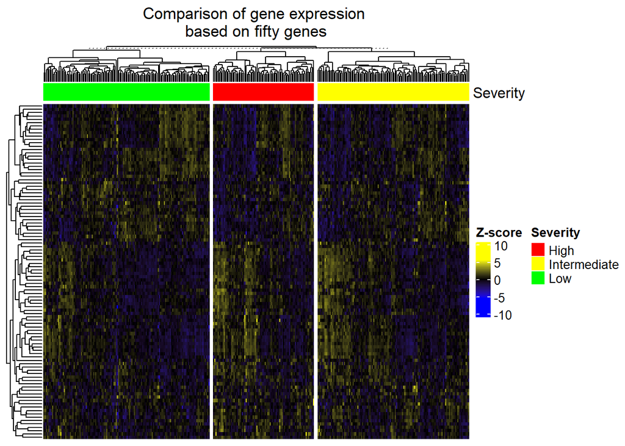

Heatmap depicting the gene expression of the top 50 most-contributing DEGs per severity level based on Z-scores.

```r
plot_heatmap(fivety_genes, meta.sepsis, 'fifty genes')
```

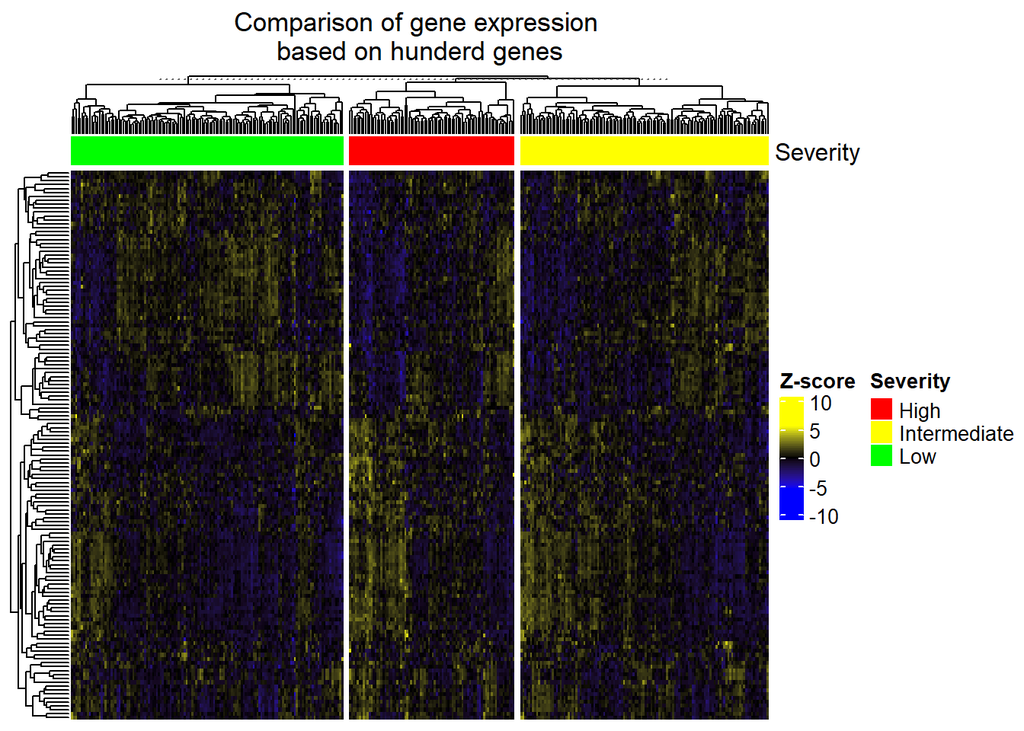

Heatmap depicting the gene expression of the top 100 most-contributing DEGs per severity level based on Z-scores.

```r
plot_heatmap(hunderth_genes, meta.sepsis, 'hunderd genes')
```

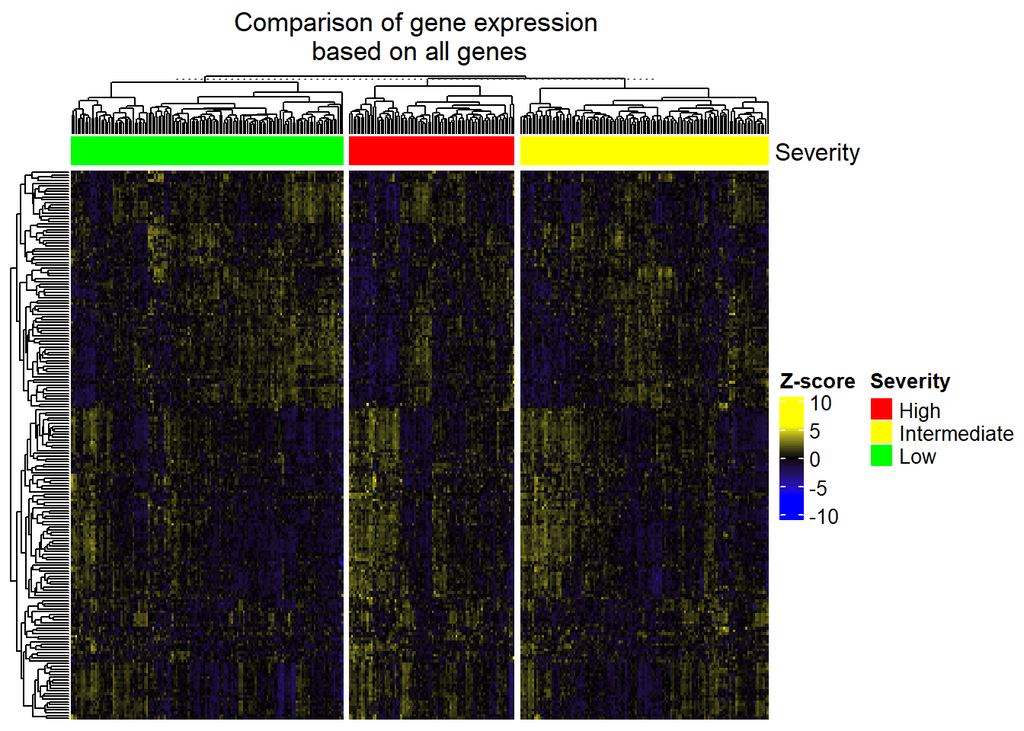

Heatmap depicting the gene expression of the DEGs per severity level based on Z-scores. We can see a distinction between gene expression patterns - some even stronger between the severity levels in comparison with the 50 and 100 sets!

```r
plot_heatmap(all_genes, meta.sepsis, 'all genes')
```

Lastly, we plot the up and downregulated DEGs per comparison with the function `plot_volcano`. We plot these with the intention of not only giving a visualization of the differences per comparison but also how large some DEGs are enriched. The p-value is based on a -log10 distribution and the fold change on a log2 distribution, which is standard for volcano plots. We highlighted the different thresholds with a grey dotted line. As we can see, the High-Low comparison yields the most DEGS, and the other two less extreme phenotype comparisons yield fewer DEGs.

```r
plot_volcano <- function(data, type) {

  # specify different indices, depending on the DE analysis package
  if (type == 'deseq2') {
    pvald <- 'padj'
    logFC <- 'log2FoldChange'
  } else {
    # parameters for edgeR
    pvald <- 'FDR'
    logFC <- 'logFC'
  }

  ggplot(data, aes(x = !!sym(logFC), y = -log10(!!sym(pvald)),
                   col = direction)) +
    geom_point(size = 1.5) +
    labs(title= glue::glue('Volcano plot -
                           DEGs found with sepsis severity ({type})'),
        color = 'Status',
        x = expression('log'[2]*'fold change'),
        y = expression('-log'[10]*"p-value")) +
    geom_vline(xintercept=c(-log2(1.2), log2(1.2)),
               linetype='dashed', col="gray") +
    # introduce breaks, as well as specific for the fold change threshold
    scale_x_continuous(breaks = c(seq(-2.5, 2.5, 0.5), -log2(1.2), log2(1.2)),
                       labels = c(seq(-2.5, 2.5, 0.5),
                                  "-log2(1.2)", "log2(1.2)")) +
    scale_y_continuous(breaks = c(seq(0.0, 10.0, 2.5), -log10(0.05)),
                       labels = c(seq(0.0, 10.0, 2.5), "p.val = 0.05")) +
    geom_hline(yintercept = -log10(0.05), linetype = 'dashed', col='gray') +
    scale_color_manual(values = c("blue", "grey", "red"),
                       labels = c("Downregulated",
                                  "Not Significant", "Upregulated"))
}

# volcano plot for every severity comparison
volcanos <- lapply(degs$results, function(comparison)
  plot_volcano(comparison, type='deseq2'))
```

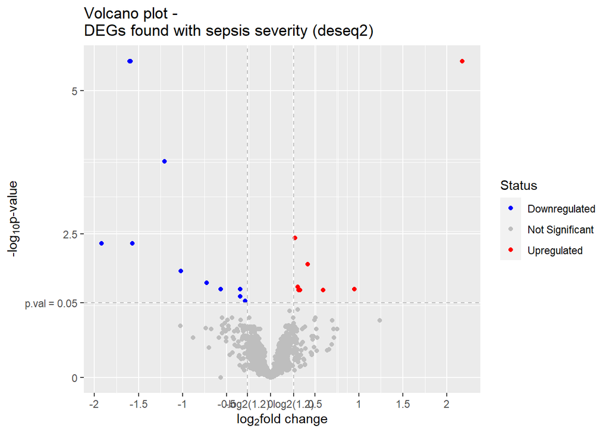

```r
plot(volcanos[[1]])
```

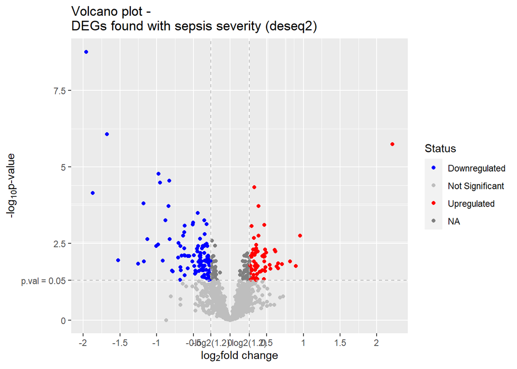

Volcano plot regarding the High-Low comparison. We have some more than 150 genes that are signficantly down or up regulated.

```r
plot(volcanos[[2]])
```

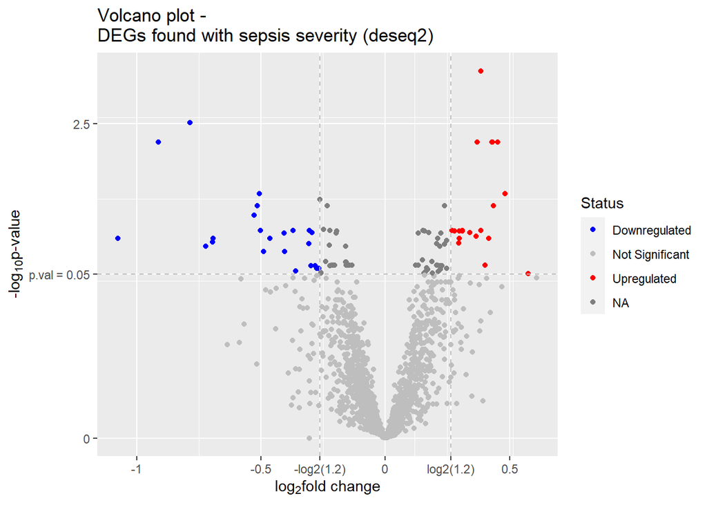

```r
plot(volcanos[[3]])
```

# DE analysis with edgeR

To validate our findings in the amount of DEGs, we turn to a different DE analysis method called edgeR. It is good to note that while both edgeR and DESeq2 are notable tools in differential analysis, both use different methods. As said earlier, DESeq2 uses a negative binomial distribution, whereas edgeR uses an empirical Bayes estimation. We expect to see some differences between the two methods.

We start off with creating a DGE object via `DGEList` and filter out low-expressed genes (having, just as with DESeq2, 1.482 genes left) with the same settings as we used for DESeq2. Thereafter, we normalize the data using trimmed mean of M-values (TMM), accounting for differences in sequencing depth. We perform batch correction in the model setup with `sequencing_month_year`. Thereafter, we calculate the dispersion estimation per gene with `estimateDisp`. We highlight findings in the biological coefficient of variation (BCV) plot. Most genes fall within the blue trend line (average dispersion estimate), suggesting that the model explains their variability. The red line is relatively flat, suggesting a single estimate across all genes. The fact that the blue line is closer to most of the points than the red line indicates that tagwise dispersion is a better fit.

```r
dge <- DGEList(counts)
# filter out low-expressed genes
keep <- rowSums(dge$counts >= 10) >= 10
dge <- dge[keep, ,]
dim(dge)
```

```
## [1] 1482  348
```

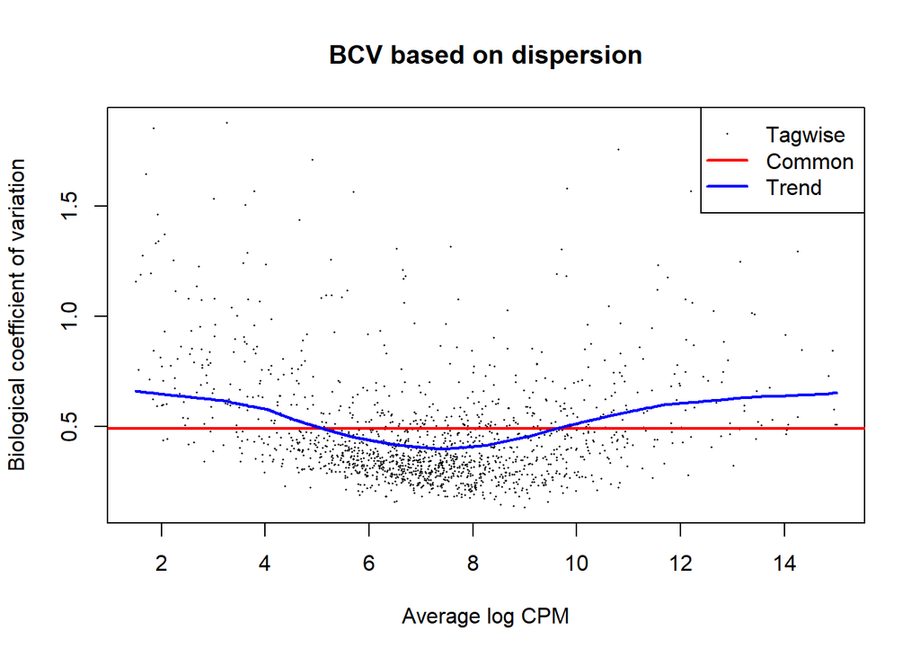

Dispersion plot with a blue line representing the average dispersion estimate. Most genes fall within this trend line, suggesting that the model explains their variability. The red line is relatively flat, suggesting a single estimate across all genes. The fact that the blue line is closer to most of the points than the red line indicates that tagwise dispersion is a better fit.

```r
# calculate norm factors
dge <- calcNormFactors(dge)

# Setting up the model with var condition
design <- model.matrix(~ sequencing_month_year +
                         sepsis_severity, data = meta.sepsis)

# Estimating the dispersion and perform a BCV
dgList <- estimateDisp(dge, design = design)
plotBCV(dgList, main = "BCV based on dispersion")
```

Now, we perform the actual extraction of significant genes with `glmQLFit` - a GLM with quasi-likelihood F-test - using the `robust=TRUE` parameter to be more robust against outliers (which our data includes, see EDA). We make contrasts to compare the levels of sepsis severity. Then, we perform the actual F-test (`glmQLFTest`) to extract the DEGs per contrast, while DEGs are identified with `decideTestsDGE`. Again, in contrast, we keep the original gene names by saving them as row names. Then, we plot a Smear plot per comparison while highlighting the found DEGs in red. Thresholds are displayed as red lines (log2(1.2) and a p-value <= 0.05). Again, we see that High-Low exhibits most DEGs. Thereafter, we get all DEGs and state whether they are up or downregulated and plot volcano plots of the result.